# Creation of the Home Based University PA Tables - RMOW model

```r
knitr::opts_chunk$set(echo = TRUE)
```

## Post Seconary Survey Analysis

Here we are batching in the survey that we got from Geoff at the Region of Waterloo. The intent is to understand **mode choice** that is currently prevalent within the Region as it pertains to post secondary travel. If the data permits, we would also like to **extract spatial patterns**, although at first glance it seems that rather than absolute numbers, we can extract the relative attractiveness of many sub-geographies within the Region as it pertains to post secondary residential choice.

### **Mode Choice** from the Survey

```r
#' read in the university dataset. The *.sav extension works better.
dataset = read.spss("C:/Projects/Waterloo/HBU Survey.sav", to.data.frame=TRUE)
```

```
C:/Projects/Waterloo/HBU Survey.sav: Unrecognized record type 7, subtype 18 encountered in system file
```

```r
#' Only keep the columns that matter for generating a PA table
data1 <- dataset[, c(4:10, 14:17, 31, 45)]
```

#### Only keep trips that corresspond to university and college trips that take place to campuses within Waterloo. Also generate a table that shows the trips by mode that the post secondary trips within Waterloo belong to.

```r
#' generate unique values for the campuses
campus <- as.data.frame(unique(data1$QS1))
colnames(campus) <- "Campuses"
  campus <- transform(campus, flag = ifelse(campus$Campuses == "Wilfrid Laurier University/Nipissing University Concurrent E", 1,
                                            ifelse(campus$Campuses == "Wilfrid Laurier University", 1,
                                                   ifelse(campus$Campuses == "University of Waterloo", 1,
                                                          ifelse(campus$Campuses == "Conestoga College", 1, 0)))))
#' subset the data using the unique values observed in the campus dataframe
data2 <- merge(data1, campus, by.x = "QS1", by.y = "Campuses", all.x = TRUE) %>%
  subset(., flag == 1 & Q2a_dk_Dontknowmainintersection == "Not Selected") %>%
  transform(., address = paste0(.$Q2a_box1, " and ", .$Q2a_box2,",", .$Q2a_box3)) %>%
  transform(., unique = seq(1, nrow(.)))
# write.csv(data2, "waterloolocations.csv", row.names = F)
#' get mode split values
ms <- data2 %>% group_by(Q7) %>% summarise(frq = n()) %>%
  transform(., Pct = round(.$frq/sum(.$frq)*100), 2)%>% subset(., Pct != 0)
# get frequecny of records by Post Secondary Institution
f <- data2 %>% group_by(QS1) %>% summarise(NofRecords = n())
datatable(f)
```

|  | QS1 | NofRecords |
| --- | --- | --- |
| 1 | Conestoga College | 534 |
| 2 | University of Waterloo | 1655 |
| 3 | Wilfrid Laurier University | 1239 |
| 4 | Wilfrid Laurier University/Nipissing University Concurrent E | 197 |

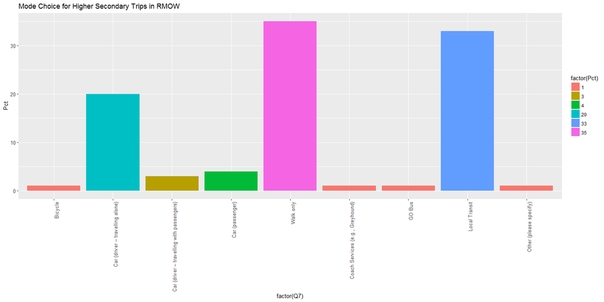

```r
#' Plot the mode splits
ggplot(ms, aes(y = Pct, x = factor(Q7), fill = factor(Pct))) +
  geom_bar(stat = "identity") + ggtitle("Mode Choice for Higher Secondary Trips in RMOW") +
  theme(axis.text = element_text(size = 10)) + theme(axis.text.x = element_text(angle = 90, hjust = 1))
```

### Extract **Spatial Patterns** from the various datasources

#### **Survey**

[output not shown]

Now **geocode** the points

```r
# bring in Nem's equivalency files
eq <- read.csv("c:/projects/waterloo/FinalUpdatedZonalHierarchy_manyToMany.csv") %>%
  group_by(WaterlooZone) %>% summarise(SZ = min(Ensemble_Zones))
#' geocode the observations
geo_other <- read.csv("c:/projects/waterloo/surveysgeocoded1.csv")
geo_rem <- read.csv("c:/projects/waterloo/surveysgeocoded2.csv")
# bind all the geocoded locations
all_geo <- rbind(geo_other, geo_rem) %>% subset(., select = -c(X))
  write.csv(all_geo, "c:/projects/waterloo/surveysgeocoded.csv")
# add in the latlong info to the survey records
data3 <- cbind(data2, all_geo) %>% .[!is.na(.$lon),]
#' create temp all_geo
all_geo1 <- all_geo[!is.na(all_geo$lon), ]
#' convert the survey records into points using the latlon
spdf_pt <- SpatialPointsDataFrame(coords = all_geo1, data = data3)
proj4string(spdf_pt) <- proj4string(sz)
# batch in the Waterloo zone system
wat <- readOGR("c:/projects/waterloo", "WatZones_LL")
#' transfer the superzone info to the waterloo shapefile
wat@data = data.frame(wat@data,eq[match(wat@data$NO,
                                                     eq$WaterlooZone),])
# Do a point in polygon analysis
spdf_wat <- point.in.poly(spdf_pt, wat)
ss <- spdf_wat@data
survey <- ss %>% group_by(SZ) %>% summarise(TotPAWat_Survey = n()) %>%
  transform(., PctWat_Sy = round(.$TotPAWat_Survey/sum(.$TotPAWat_Survey)*100),2 ) %>% subset(., select = -c(X2))
# writeOGR(obj=spdf_pt, "C:/projects/waterloo", layer = "spdf_pt", driver = "ESRI Shapefile")
```

```r
#' Superzones showing the residential activity of the survey respondents
img <- readPNG("c:/projects/waterloo/Post Secondary Resident Propensity.png")
      grid.raster(img)
```

[output not shown]

#### Now batch in the **HBU PA table** from the **RMOW model**.

The RMOW tables have been categorized by age with some overlap as the first group i.e. 10-19 also includes elementary and secondary students. In any case we are batching in the 20-29 and 30+ age groups. A certain portion of the 10-19 age category too has to be batched in.

```r
#' batch in an equiv file of zones and super zones
eq <- read.csv("c:/projects/waterloo/FinalUpdatedZonalHierarchy_manyToMany.csv") %>%
  group_by(WaterlooZone) %>% summarise(SZ = min(Ensemble_Zones))
#' Batch in the HBS PA file for age group 10-19. Nem already split this file to only contain those trip records that have at least #' one trip end within a HBU zone.
hbu0 <- read.csv("c:/projects/waterloo/HBU_10_19_Trips.csv") %>% subset(., Trips > 0) %>%
  merge(., eq, by.x = "Origin", by.y = "WaterlooZone") %>%
  merge (., eq, by.x = "Destination", by.y = "WaterlooZone")
colnames(hbu0) <- c("Origin", "Dest", "Trips", "SZ_Orig", "SZ_Dest")
#' get total PAs by Superzone Origin
sz_10_19 <- hbu0 %>% group_by(SZ_Orig) %>%
  summarise(TotPA_1019 = sum(Trips)) %>%
  transform(., TotPA_1019 = (TotPA_1019))
# Batch in the HBS PA file for age group 20-29 first
hbu1 <- read.csv("c:/projects/waterloo/HBS 20-29.csv") %>% subset(., Trips > 0) %>%
  merge(., eq, by.x = "Origin", by.y = "WaterlooZone") %>%
  merge (., eq, by.x = "Destination", by.y = "WaterlooZone")
colnames(hbu1) <- c("Origin", "Dest", "Trips", "SZ_Orig", "SZ_Dest")
#' get total PAs by Superzone Origin
sz_20_29 <- hbu1 %>% group_by(SZ_Orig) %>% summarise(TotPA_1929 = sum(Trips))
#' Now batch in the PA file for age 30+
hbu2 <- read.csv("c:/projects/waterloo/HBS 30+.csv") %>% subset(., Trips > 0) %>%
  merge(., eq, by.x = "Origin", by.y = "WaterlooZone") %>%
  merge (., eq, by.x = "Destination", by.y = "WaterlooZone")
colnames(hbu2) <- c("Origin", "Dest", "Trips", "SZ_Orig", "SZ_Dest")
#' get total PAs by Superzone Origin
sz_30 <- hbu2 %>% group_by(SZ_Orig) %>% summarise(TotPA_30 = sum(Trips))
#' Now merge the tables to show PAs being estimated by the RMOW model by superzone Origin
hbu_orig <- merge(sz_20_29, sz_30, by = "SZ_Orig") %>%
  merge(., sz_10_19, by = "SZ_Orig") %>%
  transform(., TotPAWat = .$TotPA_1929 + .$TotPA_30 + .$TotPA_1019) %>%
  transform(., PctWat = round(.$TotPAWat/sum(.$TotPAWat)*100),2) %>% subset(., select = -c(X2))
```

```r
datatable(hbu_orig)
```

|  | SZ_Orig | TotPA_1929 | TotPA_30 | TotPA_1019 | TotPAWat | PctWat |
| --- | --- | --- | --- | --- | --- | --- |
| 1 | 11 | 444.001 | 22.982 | 43.573 | 510.556 | 2 |
| 2 | 21 | 96.326 | 10.706 | 14.263 | 121.295 | 0 |
| 3 | 31 | 349.051 | 18.624 | 56.019 | 423.694 | 1 |
| 4 | 32 | 69.825 | 4.693 | 10.616 | 85.134 | 0 |
| 5 | 41 | 1607.984 | 305.566 | 444.944 | 2358.494 | 8 |
| 6 | 42 | 2043.689 | 341.492 | 861.199 | 3246.38 | 11 |
| 7 | 51 | 3221.329 | 599.455 | 1031.736 | 4852.52 | 16 |
| 8 | 61 | 937.862 | 477.264 | 282.649 | 1697.775 | 5 |
| 9 | 62 | 143.235 | 75.658 | 33.589 | 252.482 | 1 |
| 10 | 71 | 174.398 | 43.799 | 40.63 | 258.827 | 1 |

[output cut: 15 more lines]

```r
print(paste0("The RMOW model, after our adjustments for the wrong spatial locations of the various university campuses is now reporting a total of ", sum(hbu_orig$TotPAWat), " daily PAs, which equates to 13414 persons. The total enrollment in the region is 55,000. This suggests that less than **one third** the students are making a Daily Trip to any one of the campuses in the RMOW."))
```

[output not shown]

#### Batch in the **Linkage matrix** from the V4 model

Now batch in the V4 model **Linkages** from the Long Term Choice model. This model categorically reports the HBU trip and thus no further data munging is required for a comparison.

```r
sum(v4hbu_sz$ToTPALink_V4)
```

```
[1] 19490
```

### Combine all the **Spatial Patterns** together

Now let’s bring all the various data pieces together to see how the Survey, RMOW model, and the V4 model compare in terms of the resident end of the HBU linkages.

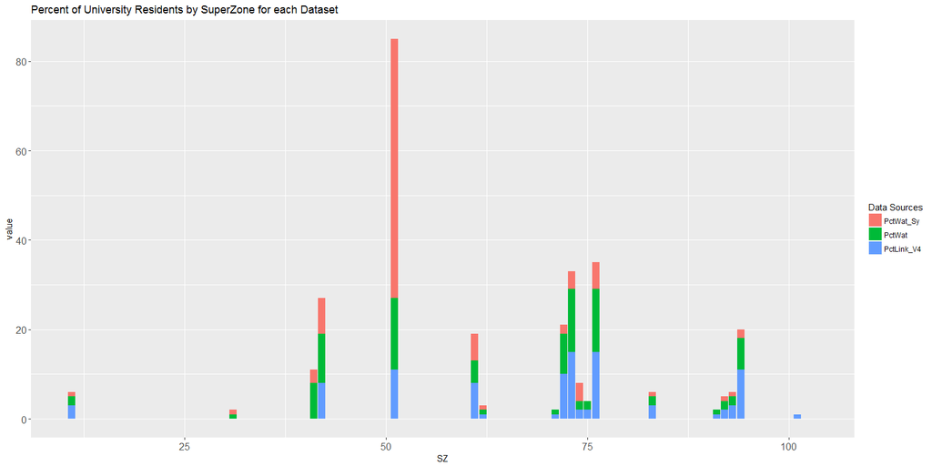

```r
#' only keep relevant columns from the RMOW model
hbu_orig1 <- subset(hbu_orig, select = c(SZ_Orig, TotPAWat, PctWat))
final <- merge(survey, hbu_orig1, by.x = "SZ", by.y = "SZ_Orig", all.y = TRUE) %>%
  merge(., v4hbu_sz, by.x = "SZ", by.y = "SZ", all.x = TRUE)
#' set NAs to zero
final[is.na(final)]<- 0
#' plot the resident ends of the HBU's from all the three sources of information.
final_long <- subset(final, select = c(SZ, PctWat_Sy, PctWat, PctLink_V4)) %>% melt(., id.vars="SZ")
# now plot
ggplot(final_long, aes(x = SZ, y = value, fill = factor(variable))) + geom_bar(sta="identity") +
  scale_fill_discrete(name = "Data Sources") +  theme(axis.text = element_text(size = 12)) +
  ggtitle("Percent of University Residents by SuperZone for each Dataset")
```

#### Thus, we will use the HBU V4 matrix as a base and scale it to first get the person linkages equal to enrollment; following which it will be scaled down to reflect that on a given day there is a 80% probability of making a trip. This probability was derived from the Survey results and calculations also done independently by Geoff@Waterloo. Once the daily trips are calculated these will be converted to represent daily ProductionAttraction tables for further use in mode choice.

#### While scaling up the V4’s HBU matrix, care will be taken to get the percentage of residents from Superzone 51 close to reality. This is the SuperZOne with the most amount of on-campus student housing. A review on the Universtity’s website has indicated that there was on-campus housing in **Superzone 51** for close to **6000 students**. This is close to **16% of the Universtiy of Waterloo’s enrollment**. We will scale the V4 matrix to reflect this target as these university residences seem to enjoy very high occupancy levels.

### Now create the HBU PAs

```r
sum(final$ToTPALink_V4_S)
```

```
[1] 36400
```

```r
sum_eq2 <- eq2 %>% group_by(TTS_Zone) %>% summarise(Cnt = n()) %>% transform(., frac = 1/Cnt)
```

[output not shown]